# Lecture 2: Version control and collaboration with Git!

Daniel Hammarström

## Why version control?

- Reproducibility and transparency → Better science
- Collaboration and robustness → Better science
- Formal structures and workflows → Better science

## Introduction to git

[figure not shown]

- git is a version control software that is installed locally
- It tracks changes to files in a specific repository (folder)
- A version history are stored in a hidden folder `.git`
- git is really good at trackning plain text files, but can also track other files…

## Introduction to GitHub

- GitHub is a collaborative platform that allows you to host version controlled repositories online
- GitHub makes it possible to share code, collaborate on developing code, host websites, and more

## A list of tools for version control

- GitHub CLI → Command line interface to GitHub
- GitHub desktop → Graphical user interface to GitHub/git

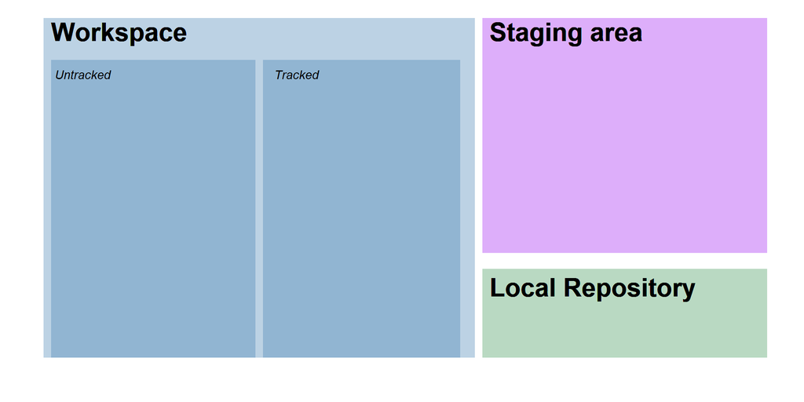

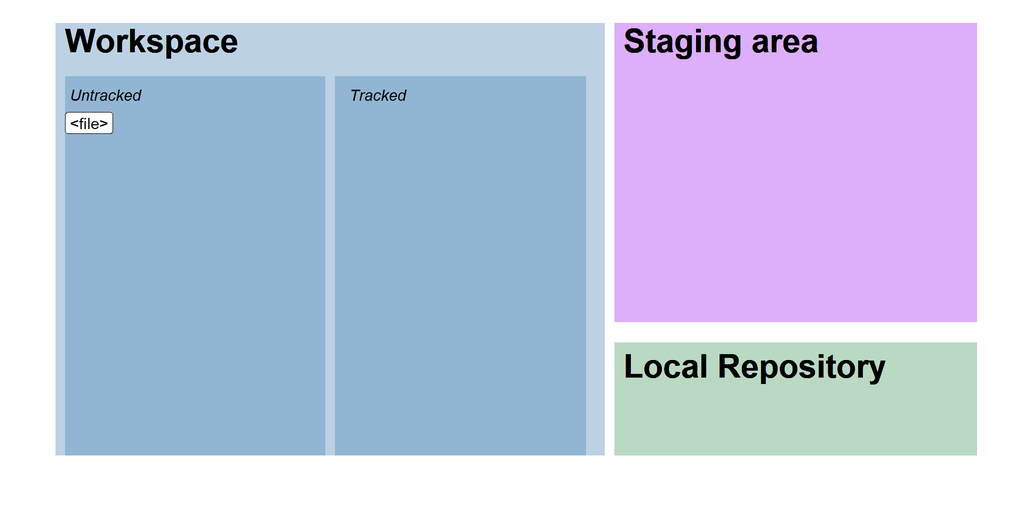

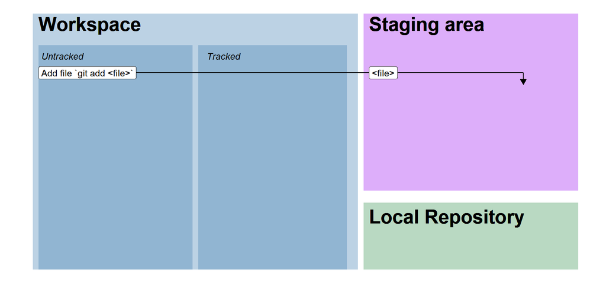

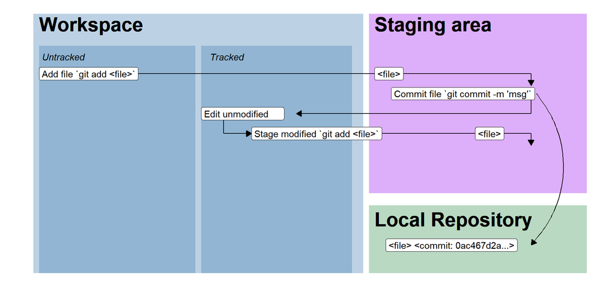

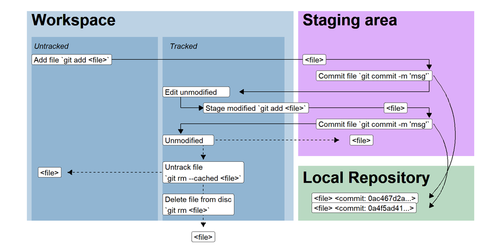

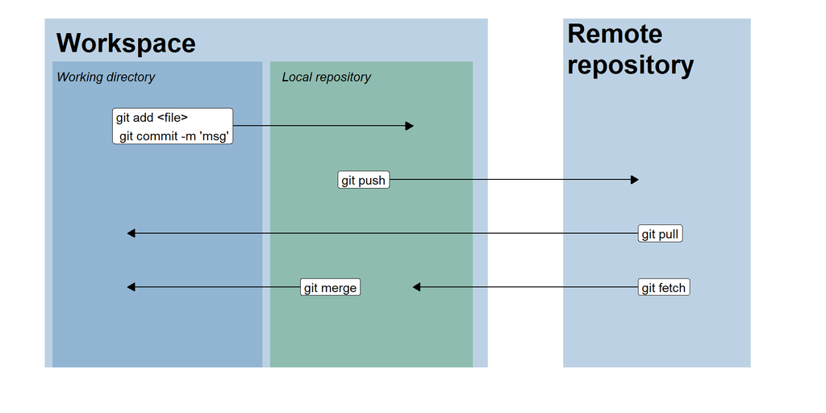

## Contributing to a central repository by pull requests

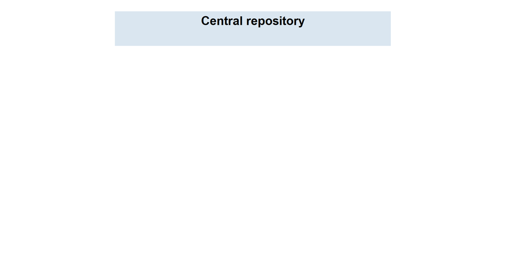

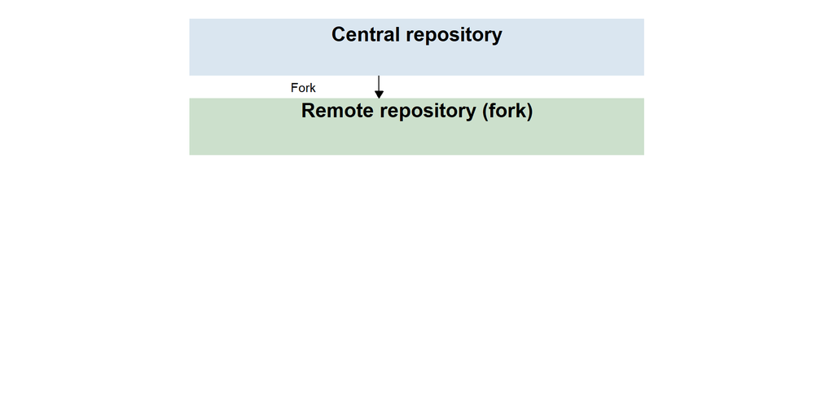

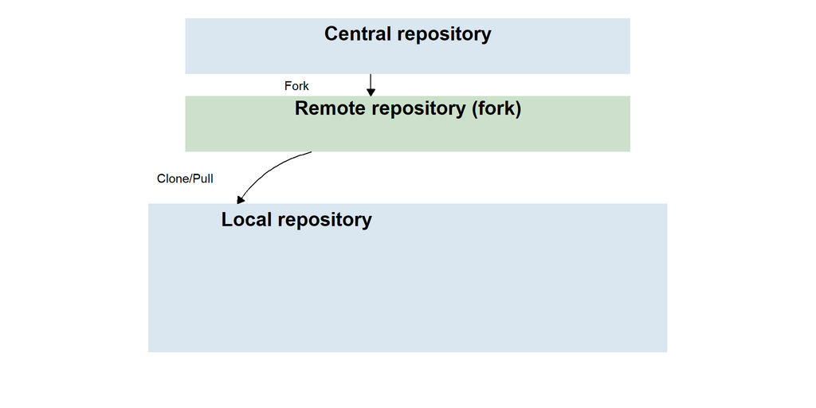

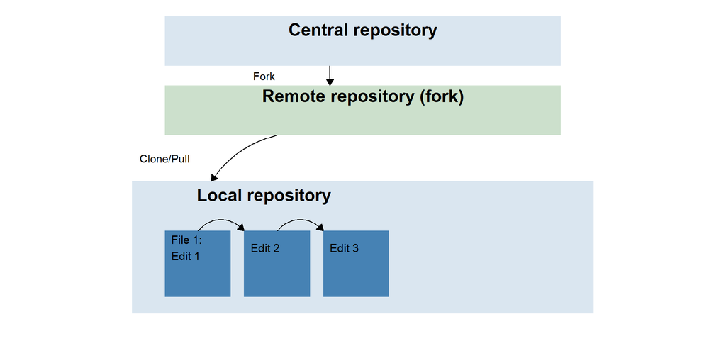

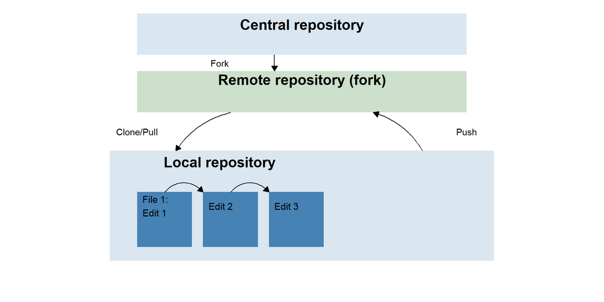

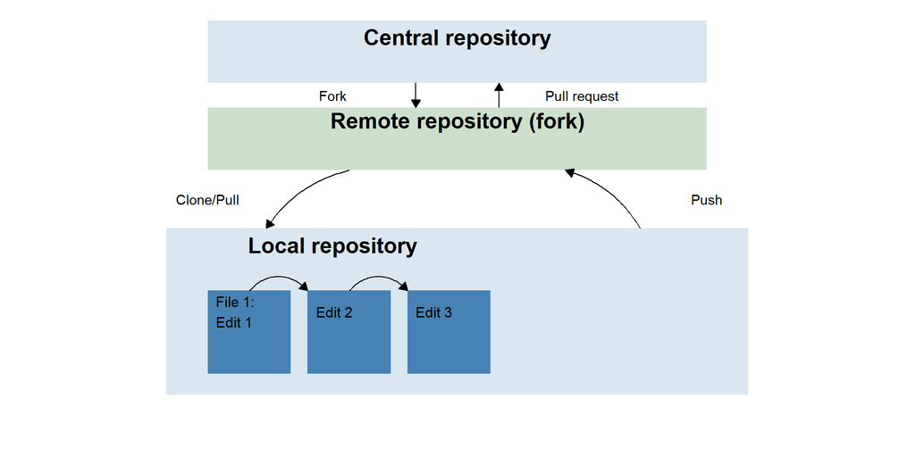

## Contributing to a central repository by pull requests

- A pull request is “all or nothing” → smaller changes are easier to pull into the central repository
- The owner of the central repository can incorporate and work on a large pull request in a separate “branch”

## Contributing to a repository by branching

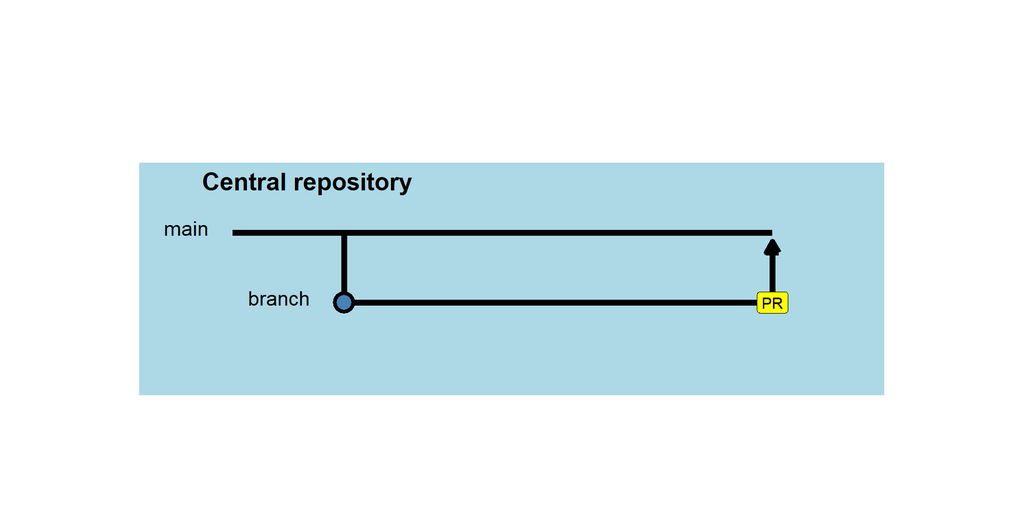

- A branch can contain edits to the project that we want to do without risking breaking the main branch.
- Changes in a branch is merged with the main branch using pull requests.

## Contributing to a repository directly by “pull” and “push”

- You could collaborate on a repository by directly pulling and push from the main branch…
- This may be risky as parallel changes to the same files creates *merge conflicts*

## Merge and conflicts

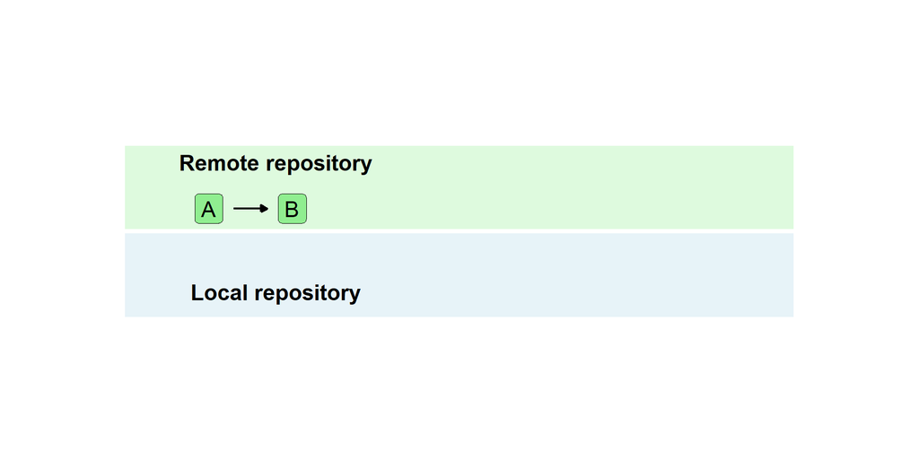

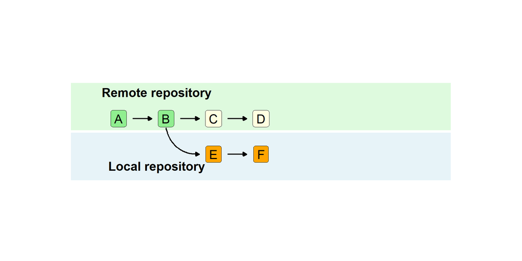

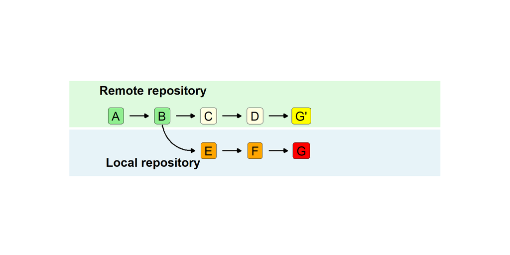

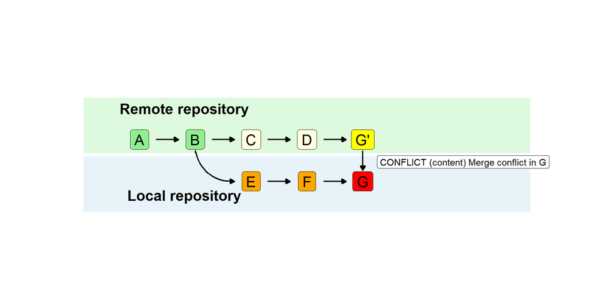

## Merge conflicts

Local repository:  
**`File-1.txt`**

```
## This is an example

It has some content that needs to be version controlled
```

Remote repository:  
**`File-1.txt`**

```
## This is an example

It has some content that needs to be version controlled. We are adding some information in the remote repository
```

Local repository:  
**`File-1.txt`**

```
## This is an example

It has some content that needs to be version controlled. Adding local changes.
```

Pull from remote:  
**`File-1.txt`**

```
## This is an example

<<<<<<< HEAD
It has some content that needs to be version controlled. Adding local changes.
=======
It has some content that needs to be version controlled. We are adding some information in the remote repository.
>>>>>>> aac1016966305b6d8dd91aea5f8194fdfb929171
```

## Merge conflicts

Local repository:  
**`File-1.txt`**

```
## This is an example

<<<<<<< HEAD
It has some content that needs to be version controlled. Adding local changes.
=======
It has some content that needs to be version controlled. We are adding some information in the remote repository.
>>>>>>> aac1016966305b6d8dd91aea5f8194fdfb929171
```

Pull from remote:  
**`File-1.txt`**

```
<<<<<<< HEAD
This is the state of the file in your copy
=======
This is what you get from the remote
>>>>>>> aac1016966305b6d8dd91aea5f8194fdfb929171
```

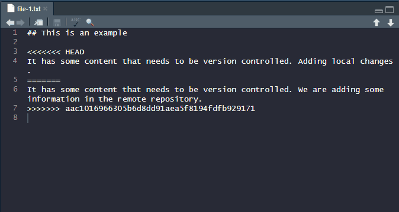

## Keep a list of files that you do not want to track with **`.gitignore`**

```
# History files
.Rhistory
.Rapp.history

# Session Data files
.RData

# User-specific files
.Ruserdata

# produced output can be rebuilt from source
*.html
*.pdf
```

- The `.gitignore` file let’s you decide what files to track in your history.
- By adding e.g. `*.pdf` and `.html` to `.gitignore` we avoid having merge conflicts in files that can be built from source.

# Git and GitHub: Best practices

- Do not push into the main/master directly, use pull requests
- Do not store sensitive information on github
- Use `.gitignore` to avoid pushing/pulling files that do not need version control.
- Do not push temporary files or files that are built from source. Add e.g. pdf-files to your `.gitignore` file.
- Write good commit messages, they should be descriptive.
- Commit often and work in small increments.
- Do not use github to store large files.
- Always “test” before commiting.